# Vanessa Santos Salgado A. Marques

Nutrition & Food Service Professional

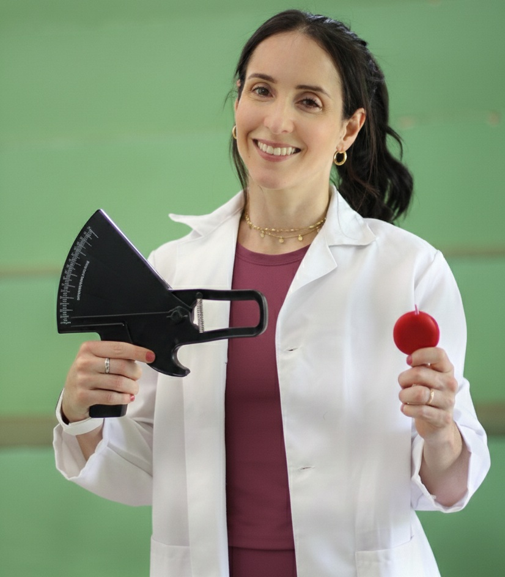

vasalga29@gmail.com

[LinkedIn Profile](https://www.linkedin.com/in/vanessamarques-nutrition-operations)

Coquitlam, BC

## Hi! I’m Vanessa!

I am a Food service and Nutrition professional with **14 years of experience** in the operations of automatic Vending Machines, food safety management, and client-centred nutrition care. Currently I am taking an **MBA at University Canada West** (2026) to complement my clinical background with strategic business insight.

**Let’s connect**!

## Education

**MBA in Artificial Intelligence and Machine Learning Leadership**  
*University Canada West, Vancouver, BC*  
Expected 2026

**BSc Nutrition**  
*Centro Universitário São Camilo, Brazil*

**Diploma, Food Technology**  
*UNICAMP, Brazil*

## My Certifications

FoodSafe Level 2(BC)

Functional Sports Nutrition Certificate

Industry Management Certificate (USP)

## Key Skills and Expertise

**Food Safety & Operations**  
Regulatory Compliance (HACCP) | Risk Management | Safety Standards (FoodSafe L2) | Quality Assurance Systems

**Clinical and Sports Nutrition**  
NICU Support | Breastfeeding Guidance | Sports Nutrition | Allergen Management | Client-Centred Care | Meal Planning & Education

**Leadership Core**  
AI Integration Strategy | Operations Management | Staff Training & Development | Quality Assurance (QA) | Performance Metrics

**Languages**  
Portuguese (Native) | English (Advanced) | Spanish (Basic)

## Community Engagement

### Food Bank Volunteer

#### Cityreach Care Society, Coquitlam, BC

July 2025 – Present

I am performing the tasks of food sorting and distribution, and assisting in providing families with safe and high-quality products.

## Signature Projects

### Sports Nutrition Workshop

#### Louveira, SP, Brazil

July 2023

I organized an educational program on pre-training and pre-competition nutrition among competitive gymnasts in Louveira, Brazil, in order that young athletes know how to nourish their bodies to maximize their physical requirements.

### Human Milk Bank

#### Hospital Geral Vila Penteado, São Paulo, Brazil

2009 (3 months)

I supported the entire milk banking life cycle, the milk collection and pasteurization process to NICU delivery and provided direct breastfeeding education, so that mothers would get the best possible support.

### Clinical Nutrition in a School Clinic

#### PROMOVE - Centro Universitário São Camilo

2009 (3 months)

I provided clinical nutrition services to underserved groups, such as an anthropometric assessment and bioimpedance analysis, to make sure that vulnerable patients could be properly diagnosed and provided with specific care.

© 2026 Vanessa Marques | Professional Portfolio